# Diseño 1: Muestreo En Dos Etapas (SISI)

## Carga de Datos y Configuración Inicial

En esta sección se inicializan los datos del departamento de Paysandú, se cargan las librerías requeridas y se ordenan los registros por la unidad de primera etapa (SEGMENTO).

```r
library(tidyverse)
library(sampling)
library(survey)

load("Paysandú.RData")
pdu <- pay

pdu$y <- ifelse(pdu$PERAL08 == 1, 1, 0)
t <- sum(pdu$y)
N <- nrow(pdu)
R <- 2000

# Ordenar el dataset para poder usar la funcion mstage
pdu <- pdu[order(pdu$SEGMENTO), ]
```

## Muestreo Bietápico Puntual

Ejecución de un único diseño en dos etapas utilizando la librería `sampling`. Se seleccionan $M = 30$ segmentos en la primera etapa y $n_i = 20$ unidades dentro de cada segmento seleccionado, sumando un tamaño de muestra final de $n = 600$.

```r
set.seed(4565)
M_muestrear <- 30
n_por_seg <- 20

muestra_dosEt <- mstage(
  pdu,
  stage = c("cluster", "cluster"),
  varnames = c("SEGMENTO", "ID_CENSO"),
  size = list(M_muestrear, rep(n_por_seg, M_muestrear)),
  method = c("srswor", "srswor")
)

# Extracción de datos de la muestra final y cálculo de pesos de Horvitz-Thompson
muestra_final_dosEt <- getdata(pdu, muestra_dosEt[[2]])
muestra_final_dosEt$w <- 1 / muestra_final_dosEt$Prob

t_est_dosEt <- sum(muestra_final_dosEt$w[muestra_final_dosEt$y == 1])
print(paste("Total estimado de asalariados privados (Puntual):", t_est_dosEt))
```

```
## [1] "Total estimado de asalariados privados (Puntual): 13523.5916666667"
```

## Estimación con Librería Survey

Validación de la estimación del total y su error estándar mediante el objeto de diseño complejo de la librería `survey`.

```r
p3_pdu <- svydesign(
  ids = ~SEGMENTO + ID_CENSO,
  probs = ~Prob,
  data = muestra_final_dosEt
)

total_svy <- svytotal(~I(y == 1), design = p3_pdu)
print(total_svy)
```

```
##                total     SE
## I(y == 1)FALSE 55111 5152.7
## I(y == 1)TRUE  13524 1965.6
```

```r
#De la salida importa solo los resultados de TRUE
```

## Simulación (Distribución Empírica)

Se ejecuta la simulación iterativa a lo largo de las $R = 2000$ réplicas para evaluar el comportamiento del estimador de Horvitz-Thompson bajo el diseño bietápico (SISI).

```r
totales_SISI <- numeric(R)
M_total <- length(unique(pdu$SEGMENTO))

set.seed(4565)

poblacion_por_seg <- pdu %>%
  group_by(SEGMENTO) %>%
  summarise(N_i = n(), .groups = "drop")

for (i in 1:R) {
  # 1. Selección de Unidades de Primera Etapa
  segmentos_elegidos <- sample(poblacion_por_seg$SEGMENTO, size = M_muestrear, replace = FALSE)
  sub_poblacion <- pdu[pdu$SEGMENTO %in% segmentos_elegidos, ]

  # 2. Selección de Unidades de Segunda Etapa
  muestra_loop <- sub_poblacion %>%
    group_by(SEGMENTO) %>%
    slice_sample(n = n_por_seg, replace = FALSE) %>%
    ungroup()

  # Asociación de tamaños poblacionales para el cálculo de probabilidades
  muestra_loop <- muestra_loop %>%
    left_join(poblacion_por_seg, by = "SEGMENTO")

  # Calculo de probabilidad conjunta y ponderador
  muestra_loop$Prob_conjunta <- (M_muestrear / M_total) * (n_por_seg / muestra_loop$N_i)
  muestra_loop$w <- 1 / muestra_loop$Prob_conjunta

  totales_SISI[i] <- sum(muestra_loop$w[muestra_loop$y == 1])
}
```

## Análisis de Eficiencia (Deff)

Para evaluar el Efecto de Diseño ($Deff$) en este esquema en dos etapas, contrastamos la varianza empírica del estimador $SISI$ frente a la varianza de un diseño de Muestreo Aleatorio Simple ($SI$) con un tamaño de muestra equivalente y fijo de $n = 600$. Importamos de forma directa los resultados del primer diseño para evitar procesos de simulación redundantes.

```r
# Cargamos los resultados de la simulación del Muestreo Simple
load("sim_si.RData")

var_mas  <- var(totales_si)
var_sisi <- var(totales_SISI)
deff     <- var_sisi / var_mas

cat("Varianza MAS:", var_mas, "\n")
```

```
## Varianza MAS: 1407003
```

```r
cat("Varianza En Dos Etapas (SISI):", var_sisi, "\n")
```

```
## Varianza En Dos Etapas (SISI): 2505207
```

```r
cat("Efecto de Diseño (Deff):", deff, "\n")
```

```
## Efecto de Diseño (Deff): 1.780527
```

## Visualización de las Distribuciones Empíricas

A continuación, se presenta la comparación gráfica de las densidades empíricas. Se superponen la curva del Muestreo Simple de control (importada) y la del diseño en dos etapas (SISI). La forma de la distribución del estimador bietápico refleja el impacto en la variabilidad que genera la selección por conglomerados en la primera etapa.

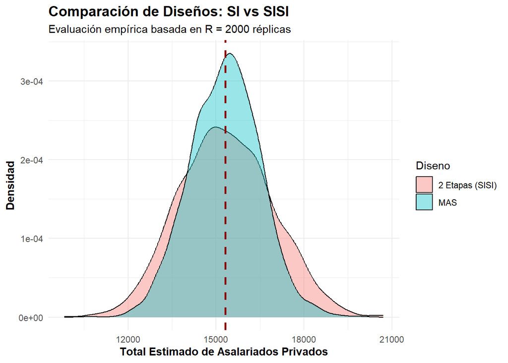

```r
resultados_grafico <- data.frame(
  Diseno = rep(c("MAS", "2 Etapas (SISI)"), each = R),
  Estimacion = c(totales_si, totales_SISI)
)

ggplot(resultados_grafico, aes(x = Estimacion, fill = Diseno)) +
  geom_density(alpha = 0.4) +
  geom_vline(xintercept = t, linetype = "dashed", color = "darkred", linewidth = 1) +
  labs(
    title = "Comparación de Diseños: SI vs SISI",
    subtitle = paste("Evaluación empírica basada en R =", R, "réplicas"),
    x = "Total Estimado de Asalariados Privados",
    y = "Densidad"
  ) +
  theme_minimal() +
  theme(
    plot.title = element_text(face = "bold", size = 14),
    axis.title = element_text(face = "bold")
  )
```

## Intervalos de Confianza

Determinación del intervalo de confianza empírico por percentiles y bajo el supuesto de normalidad asintótica para el diseño en dos etapas.

```r
alpha <- 0.05

# 1. Intervalo de Confianza Empírico
ic_SISI_empirico <- quantile(totales_SISI, probs = c(alpha / 2, 1 - alpha / 2))

# 2. Intervalo de Confianza Asumiendo Normalidad
media_SISI <- mean(totales_SISI)
sd_SISI    <- sd(totales_SISI)
z_val      <- qnorm(1 - alpha / 2)

ic_SISI_normal <- c(media_SISI - z_val * sd_SISI, media_SISI + z_val * sd_SISI)

# Resiultados
cat("--- Intervalo de Confianza Empírico (SISI) ---\n",
    "IC 95%: [", ic_SISI_empirico[1], ", ", ic_SISI_empirico[2], "]\n\n",
    "--- Intervalo Asumiendo Normalidad (SISI) ---\n",
    "IC 95%: [", ic_SISI_normal[1], ", ", ic_SISI_normal[2], "]\n")
```

```
## --- Intervalo de Confianza Empírico (SISI) ---
##  IC 95%: [ 12418.15 ,  18422.9 ]
##
##  --- Intervalo Asumiendo Normalidad (SISI) ---
##  IC 95%: [ 12237.49 ,  18441.89 ]
```